# Sessions 5-6

T. Evgeniou

In this session (and report) we combine the report of [sessions 3-4](http://inseaddataanalytics.github.io/INSEADAnalytics/Session2inclass.html) to complete the [Boats cases A](http://inseaddataanalytics.github.io/INSEADAnalytics/Boats-A-prerelease.pdf) and [B](http://inseaddataanalytics.github.io/INSEADAnalytics/Boats-B-prerelease.pdf).

The purpose of this session is to become familiar with:

1. Understand the use of segmentation in practice;
2. Learn about classification and scoring methods;
3. See how these tools can be used in practice;
4. Introduce advanced methods for data analytics

The first part of this report is identical to that of [sessions 3-4](http://inseaddataanalytics.github.io/INSEADAnalytics/Session2inclass.html), hence you can move to the last part . The content is repeated so that we have the complete solution of the Boats case all in one report

As always, before starting, make sure you have pulled the [session 5-6 files](https://github.com/InseadDataAnalytics/INSEADAnalytics/tree/master/CourseSessions/Sessions56) (yes, I know, it says sessions 4-5, but it is 5-6 - need to update all filenames some time, but till then we use common sense and ignore a bit the filenames) on your github repository (if you pull the course github repository you also get the session files automatically). Moreover, make sure you are in the directory of this exercise. Directory paths may be complicated, and sometimes a frustrating source of problems, so it is recommended that you use these R commands to find out your current working directory and, if needed, set it where you have the main files for the specific exercise/project (there are other ways, but for now just be aware of this path issue). For example, assuming we are now in the “MYDIRECTORY/INSEADAnalytics” directory, we can do these:

```r
getwd()
setwd("CourseSessions/Sessions45")
list.files()
rm(list = ls())  # Clean up the memory, if we want to rerun from scratch
```

As always, you can use the `help` command in Rstudio to find out about any R function (e.g. type `help(list.files)` to learn what the R function `list.files` does).

Let’s start.

### Survey Data for Market Segmentation

We will be using the [boats case study](http://inseaddataanalytics.github.io/INSEADAnalytics/Boats-A-prerelease.pdf) as an example. At the end of this class we will be able to develop (from scratch) the readings of sessions 3-4 as well as understand the tools used and the interpretation of the results in practice - in order to make business decisions. The code used here is along the lines of the code in the session directory, e.g. in the RunStudy.R file and the report [doc/Report_s23.Rmd.](https://github.com/InseadDataAnalytics/INSEADAnalytics/blob/master/CourseSessions/Sessions23/doc/Report_s23.Rmd) There may be a few differences, as there are many ways to write code to do the same thing.

Let’s load the data:

```r
ProjectData <- read.csv("data/Boats.csv", sep = ";", dec = ",")  # this contains only the matrix ProjectData
ProjectData = data.matrix(ProjectData)
colnames(ProjectData) <- gsub("\\.", " ", colnames(ProjectData))
ProjectDataFactor = ProjectData[, c(2:30)]
```

#### Questions

1. Do you see any high correlations between the responses? Do they make sense?
2. What do these correlations imply?

##### Answers:

### Key Customer Attitudes

Clearly the survey asked many reduntant questions (can you think some reasons why?), so we may be able to actually “group” these 29 attitude questions into only a few “key factors”. This not only will simplify the data, but will also greatly facilitate our understanding of the customers.

To do so, we use methods called [Principal Component Analysis](https://en.wikipedia.org/wiki/Principal_component_analysis) and [factor analysis](https://en.wikipedia.org/wiki/Factor_analysis) as discussed in the [session readings](http://inseaddataanalytics.github.io/INSEADAnalytics/Report_s23.html). We can use two different R commands for this (they make slightly different information easily available as output): the command `principal` (check `help(principal)` from R package [psych](http://personality-project.org/r/psych/)), and the command `PCA` from R package [FactoMineR](http://factominer.free.fr) - there are more packages and commands for this, as these methods are very widely used.

Here is how the `principal` function is used:

```r
UnRotated_Results <- principal(ProjectDataFactor, nfactors = ncol(ProjectDataFactor),
    rotate = "none", score = TRUE)
UnRotated_Factors <- round(UnRotated_Results$loadings, 2)
UnRotated_Factors <- as.data.frame(unclass(UnRotated_Factors))
colnames(UnRotated_Factors) <- paste("Component", 1:ncol(UnRotated_Factors),
    sep = " ")
```

Here is how we use `PCA` one is used:

```r
Variance_Explained_Table_results <- PCA(ProjectDataFactor, graph = FALSE)
Variance_Explained_Table <- Variance_Explained_Table_results$eig
Variance_Explained_Table_copy <- Variance_Explained_Table
row = 1:nrow(Variance_Explained_Table)
name <- paste("Component No:", row, sep = "")
Variance_Explained_Table <- cbind(name, Variance_Explained_Table)
Variance_Explained_Table <- as.data.frame(Variance_Explained_Table)
colnames(Variance_Explained_Table) <- c("Components", "Eigenvalue", "Percentage_of_explained_variance",
    "Cumulative_percentage_of_explained_variance")

eigenvalues <- Variance_Explained_Table[, 2]
```

#### Questions:

**Your Answers here:**

#### Visualization and Interpretation

```r
# Choose one of these options:
factors_selected = sum(Variance_Explained_Table_copy[, 1] >= 1)
# minimum_variance_explained = 0.5; factors_selected =
# 1:head(which(Variance_Explained_Table_copy[,'cumulative percentage of
# variance']>= minimum_variance_explained),1) factors_selected = 10
```

To better visualise them, we will use what is called a “rotation”. There are many rotations methods, we use what is called the [varimax](http://stats.stackexchange.com/questions/612/is-pca-followed-by-a-rotation-such-as-varimax-still-pca) rotation:

```r
# Please ENTER the rotation eventually used (e.g. 'none', 'varimax',
# 'quatimax', 'promax', 'oblimin', 'simplimax', and 'cluster' - see
# help(principal)). Defauls is 'varimax'
rotation_used = "varimax"
```

```r
Rotated_Results <- principal(ProjectDataFactor, nfactors = max(factors_selected),
    rotate = rotation_used, score = TRUE)
Rotated_Factors <- round(Rotated_Results$loadings, 2)
Rotated_Factors <- as.data.frame(unclass(Rotated_Factors))
colnames(Rotated_Factors) <- paste("Component", 1:ncol(Rotated_Factors), sep = " ")
sorted_rows <- sort(Rotated_Factors[, 1], decreasing = TRUE, index.return = TRUE)$ix
Rotated_Factors <- Rotated_Factors[sorted_rows, ]
```

```r
MIN_VALUE = 0.5
Rotated_Factors_thres <- Rotated_Factors
Rotated_Factors_thres[abs(Rotated_Factors_thres) < MIN_VALUE] <- NA
colnames(Rotated_Factors_thres) <- colnames(Rotated_Factors)
rownames(Rotated_Factors_thres) <- rownames(Rotated_Factors)
```

#### Questions

1. What do the first couple of factors mean? Do they make business sense?
2. How many factors should we choose for this data/customer base? Please try a few and explain your final choice based on a) statistical arguments, b) on interpretation arguments, c) on business arguments (**you need to consider all three types of arguments**)
3. How would you interpret the factors you selected?
4. What lessons about data science do you learn when doing this analysis? Please comment.
5. (Extra/Optional) Can you make this report “dynamic” using shiny and then post it on shinyapps.io? (see for example exercise set 1 and interactive exercise set 2)

**Your Answers here:**

### Market Segmentation

Let’s now use one representative question for each factor (we can also use the “factor scores” for each respondent - see [session readings](http://inseaddataanalytics.github.io/INSEADAnalytics/Report_s23.html)) to represent our survey respondents. We can choose the question with the highest absolute factor loading for each factor. For example, when we use 5 factors with the varimax rotation we can select questions Q.1.9 (I see my boat as a status symbol), Q1.18 (Boating gives me a feeling of adventure), Q1.4 (I only consider buying a boat from a reputable brand), Q1.11 (I tend to perform minor boat repairs and maintenance on my own) and Q1.2 (When buying a boat getting the lowest price is more important than the boat brand) - try it. These are columns 10, 19, 5, 12, and 3, respectively of the data matrix `Projectdata`.

In market segmentation one may use variables to **profile** the segments which are not the same (necessarily) as those used to **segment** the market: the latter may be, for example, attitude/needs related (you define segments based on what the customers “need”), while the former may be any information that allows a company to identify the defined customer segments (e.g. demographics, location, etc). Of course deciding which variables to use for segmentation and which to use for profiling (and then **activation** of the segmentation for business purposes) is largely subjective. So in this case we will use all survey questions for profiling for now:

```r
segmentation_attributes_used = c(10, 19, 5, 12, 3)
profile_attributes_used = 2:ncol(ProjectData)
ProjectData_segment = ProjectData[, segmentation_attributes_used]
ProjectData_profile = ProjectData[, profile_attributes_used]
```

A key family of methods used for segmenation is what is called **clustering methods**. This is a very important problem in statistics and **machine learning**, used in all sorts of applications such as in [Amazon’s pioneer work on recommender systems](http://www.cs.umd.edu/~samir/498/Amazon-Recommendations.pdf). There are many *mathematical methods* for clustering. We will use two very standard methods, **hierarchical clustering** and **k-means**. While the “math” behind all these methods can be complex, the R functions used are relatively simple to use, as we will see.

For example, to use hierarchical clustering we simply first define some parameters used (see session readings) and then simply call the command `hclust`:

```r
# Please ENTER the distance metric eventually used for the clustering in
# case of hierarchical clustering (e.g. 'euclidean', 'maximum', 'manhattan',
# 'canberra', 'binary' or 'minkowski' - see help(dist)).  DEFAULT is
# 'euclidean'
distance_used = "euclidean"
# Please ENTER the hierarchical clustering method to use (options are:
# 'ward', 'single', 'complete', 'average', 'mcquitty', 'median' or
# 'centroid') DEFAULT is 'ward.D'
hclust_method = "ward.D"
# Define the number of clusters:
numb_clusters_used = 3
```

```r
Hierarchical_Cluster_distances <- dist(ProjectData_segment, method = distance_used)
Hierarchical_Cluster <- hclust(Hierarchical_Cluster_distances, method = hclust_method)

# Assign observations (e.g. people) in their clusters
cluster_memberships_hclust <- as.vector(cutree(Hierarchical_Cluster, k = numb_clusters_used))
cluster_ids_hclust = unique(cluster_memberships_hclust)
ProjectData_with_hclust_membership <- cbind(1:length(cluster_memberships_hclust),
    cluster_memberships_hclust)
colnames(ProjectData_with_hclust_membership) <- c("Observation Number", "Cluster_Membership")
```

Finally, we can see the **dendrogram** (see class readings and online resources for more information) to have a first rough idea of what segments (clusters) we may have - and how many.

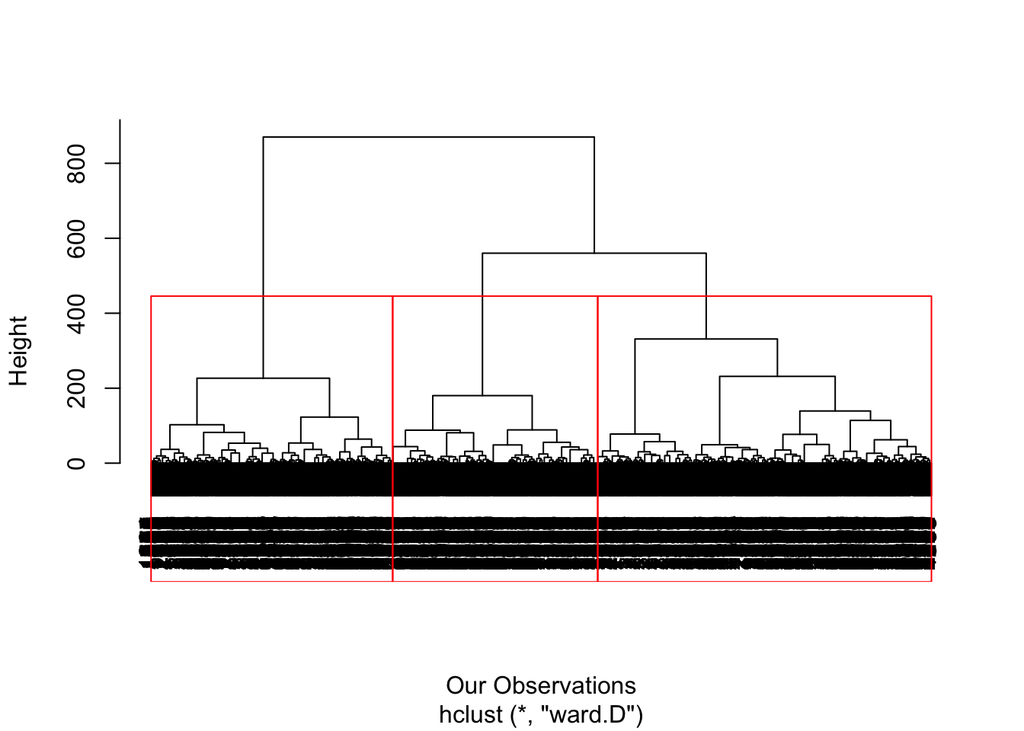

To use k-means on the other hand one needs to define a priori the number of segments (which of course one can change and re-cluster). K-means also requires the choice of a few more parameters, but this is beyond our scope for now. Here is how to run K-means:

```r
# Please ENTER the kmeans clustering method to use (options are:
# 'Hartigan-Wong', 'Lloyd', 'Forgy', 'MacQueen' DEFAULT is 'Lloyd'
kmeans_method = "Lloyd"
# Define the number of clusters:
numb_clusters_used = 3
kmeans_clusters <- kmeans(ProjectData_segment, centers = numb_clusters_used,
    iter.max = 2000, algorithm = kmeans_method)
ProjectData_with_kmeans_membership <- cbind(1:length(kmeans_clusters$cluster),
    kmeans_clusters$cluster)
colnames(ProjectData_with_kmeans_membership) <- c("Observation Number", "Cluster_Membership")

# Assign observations (e.g. people) in their clusters
cluster_memberships_kmeans <- kmeans_clusters$cluster
cluster_ids_kmeans <- unique(cluster_memberships_kmeans)
```

K-means does not provide much information about segmentation. However, when we profile the segments we can start getting a better (business) understanding of what is happening. **Profiling** is a central part of segmentation: this is where we really get to mix technical and business creativity.

### Profiling

There are many ways to do the profiling of the segments. For example, here we show how the *average* answers of the respondents *in each segment* compare to the *average answer of all respondents* using the ratio of the two. The idea is that if in a segment the average response to a question is very different (e.g. away from ratio of 1) than the overall average, then that question may indicate something about the segment relative to the total population.

```r
# Select whether to use the Hhierarchical clustering or the k-means
# clusters:

cluster_memberships <- cluster_memberships_hclust
cluster_ids <- cluster_ids_hclust
# here is the k-means: uncomment these 2 lines cluster_memberships <-
# cluster_memberships_kmeans cluster_ids <- cluster_ids_kmeans

population_average = matrix(apply(ProjectData_profile, 2, mean), ncol = 1)
colnames(population_average) <- "Population"
Cluster_Profile_mean <- sapply(sort(cluster_ids), function(i) apply(ProjectData_profile[(cluster_memberships ==
    i), ], 2, mean))
if (ncol(ProjectData_profile) < 2) Cluster_Profile_mean = t(Cluster_Profile_mean)
colnames(Cluster_Profile_mean) <- paste("Segment", 1:length(cluster_ids), sep = " ")
cluster.profile <- cbind(population_average, Cluster_Profile_mean)
```

```r
ratio_limit = 0.1
```

```r
population_average_matrix <- population_average[, "Population", drop = F] %*%
    matrix(rep(1, ncol(Cluster_Profile_mean)), nrow = 1)
cluster_profile_ratios <- (ifelse(population_average_matrix == 0, 0, Cluster_Profile_mean/population_average_matrix))
colnames(cluster_profile_ratios) <- paste("Segment", 1:ncol(cluster_profile_ratios),
    sep = " ")
rownames(cluster_profile_ratios) <- colnames(ProjectData)[profile_attributes_used]
## printing the result in a clean-slate table
```

```r
# Save the segment profiles in a file: enter the name of the file!
profile_file = "my_segmentation_profiles.csv"
write.csv(cluster_profile_ratios, file = profile_file)
# We can also save the cluster membership of our respondents:
data_with_segment_membership = cbind(cluster_memberships, ProjectData)
colnames(data_with_segment_membership)[1] = "Segment"
cluster_file = "my_segments.csv"
write.csv(data_with_segment_membership, file = cluster_file)
```

**The further a ratio is from 1, the more important that attribute is for a segment relative to the total population.**

#### Questions

1. How many segments are there in our market? Why you chose that number of segments? Again, try a few and explain your final choice based on a) statistical arguments, b) on interpretation arguments, c) on business arguments (**you need to consider all three types of arguments**)
2. Can you describe the segments you found based on the profiles?
3. What if you change the number of factors and in general you *iterate the whole analysis*? **Iterations** are key in data science.
4. Can you now answer the [Boats case questions](http://inseaddataanalytics.github.io/INSEADAnalytics/Boats-A-prerelease.pdf)? What business decisions do you recommend to this company based on your analysis?

**Your Answers here:**

### Discrmininant Analysis and Scoring (New Material)

We will now use the [classification methods discussed in the readings of sessions 5-6](http://inseaddataanalytics.github.io/INSEADAnalytics/Report_s67.html). Most code will be like in the [source code of that reading.](https://github.com/InseadDataAnalytics/INSEADAnalytics/blob/master/CourseSessions/Sessions67/doc/Report_s67.Rmd)

We are interested in understanding the key purchase drivers for boats (a similar analysis can be done for recommendation drivers). To do so, we use the the so called **classification and scoring** methods. We will follow the process discussed in [the readings of sessions 5-6](http://inseaddataanalytics.github.io/INSEADAnalytics/Report_s67.html).

#### Step 1: Splitting the data into estimation and validation samples

Let’s do the split of the data in *estimation*, *validation*, and *test* using these percentages of splits:

```r
estimation_data_percent = 60
validation_data_percent = 20
test_data_percent = 100 - estimation_data_percent - validation_data_percent

# Then just define the rows we use for each of the 3 subsets of data
estimation_data_ids = 1:floor(estimation_data_percent * nrow(ProjectData)/100)
non_estimation_data = setdiff(1:nrow(ProjectData), estimation_data_ids)
validation_data_ids = (tail(estimation_data_ids, 1) + 1):(tail(estimation_data_ids,
    1) + floor(validation_data_percent/(validation_data_percent + test_data_percent) *
    length(non_estimation_data)))
test_data_ids = setdiff(1:nrow(ProjectData), union(estimation_data_ids, validation_data_ids))
```

The three sets we will use are then:

```r
estimation_data=ProjectData[estimation_data_ids,]
validation_data=ProjectData[validation_data_ids,]
test_data=ProjectData[test_data_ids,]
```

**Question:**

1. Why did we do this split of the data?

**Your Answer**

#### Step 2: Setting up the dependent variable

We are interested in understanding the purchase drivers, hence our **dependent** variable is column 82 of the Boats data (Q18_PurchaseFuture) - why is that? We will use only the subquestions of **Question 16** of the case for now:

```r
dependent_variable= 82 # Q18_PurchaseFuture
independent_variables= c(54:80) # use columns 54-80 for boats, corresponding to Question 16
```

**Question:**

1. Why does this step matter?

**Your Answer**

#### Step 3: Make a preliminary assessment of the relative importance of the explanatory variables using visualization tools and simple descriptive statistics.

**Question:**

Do you see any difference between the two groups of people? How would you classify them if you were to just look at this sample data?

**Answer**

#### Step 4: Estimate the classification model using the estimation data, and interpret the results.

We now need to use one of the many classification methods available. This is a **huge** field with many methods that people in **machine learning** often use. Here are just two resources to begin with:

1. As always there are many [R packages](https://cran.r-project.org/web/views/MachineLearning.html) for everything developed since the begining of the universe - including the recent “in fashion” methods on [deep learning](http://deeplearning.net) that companies like [Facebook](https://research.facebook.com/ai) - and [various news here](http://www.bloomberg.com/news/articles/2015-12-08/why-2015-was-a-breakthrough-year-in-artificial-intelligence) or [here](http://www.bloomberg.com/news/articles/2015-12-08/why-2015-was-a-breakthrough-year-in-artificial-intelligence) or [here](http://www.forbes.com/sites/anthonykosner/2014/12/29/tech-2015-deep-learning-and-machine-intelligence-will-eat-the-world/#3e2e74bf282c) for example - or [**Google’s this week’s Go achievement**](http://www.technologyreview.com/news/546066/googles-ai-masters-the-game-of-go-a-decade-earlier-than-expected/) proudly publisizes (e.g. [**Wall Street Journal, January 27, 2016**](http://www.wsj.com/articles/alphabet-units-artificial-intelligence-program-wins-major-victory-1453917602) ).
2. [Microsoft has a large collection of methods they develop](https://azure.microsoft.com/en-us/documentation/articles/machine-learning-algorithm-choice/)

We will use here one well known method called **Classification and Regression Trees**. Another method, **logistic regression** is also discussed in the session’s readings.

Here is how we use this method:

First we setup a so called **complexity control** which is **crucial** in data analytics and machine learning.

```r
CART_cp = 0.01
```

For better readability of the tree figures below, we also first rename the independent variables as IV1 to IV27 when using CART):

```r
# just name the variables numerically so that they look ok on the tree plots
independent_variables_nolabel = paste("IV", 1:length(independent_variables),
    sep = "")

estimation_data_nolabel = cbind(estimation_data[, dependent_variable], estimation_data[,
    independent_variables])
colnames(estimation_data_nolabel) <- c(colnames(estimation_data)[dependent_variable],
    independent_variables_nolabel)

validation_data_nolabel = cbind(validation_data[, dependent_variable], validation_data[,
    independent_variables])
colnames(validation_data_nolabel) <- c(dependent_variable, independent_variables_nolabel)

test_data_nolabel = cbind(test_data[, dependent_variable], test_data[, independent_variables])
colnames(test_data_nolabel) <- c(dependent_variable, independent_variables_nolabel)

estimation_data_nolabel = data.frame(estimation_data_nolabel)
validation_data_nolabel = data.frame(validation_data_nolabel)
test_data_nolabel = data.frame(test_data_nolabel)

estimation_data = data.frame(estimation_data)
validation_data = data.frame(validation_data)
test_data = data.frame(test_data)
```

Now we just use the usual 1-line command to let R do the “one-liner magic”:

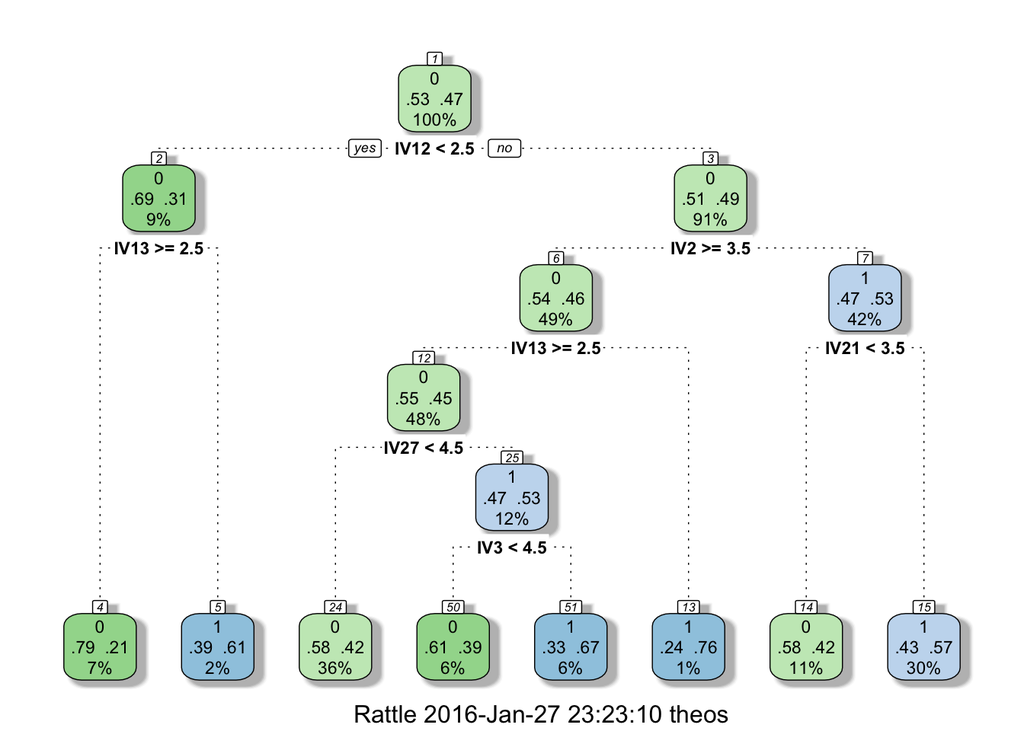

```r
# Make sure you installed these libraries first!
library(rpart)
library(rattle)
library(rpart.plot)

formula = paste(colnames(estimation_data)[dependent_variable], paste(Reduce(paste,
    sapply(head(independent_variables_nolabel, -1), function(i) paste(i, "+",
        sep = ""))), tail(independent_variables_nolabel, 1), sep = ""), sep = "~")

CART_tree <- rpart(formula, data = estimation_data_nolabel, method = "class",
    control = rpart.control(cp = CART_cp))

fancyRpartPlot(CART_tree)
```

Note that the R command `rpart` needs a “formula”. In this case the command above creates the exists `formula`:

Q18_PurchaseFuture~IV1+ IV2+ IV3+ IV4+ IV5+ IV6+ IV7+ IV8+ IV9+ IV10+ IV11+ IV12+ IV13+ IV14+ IV15+ IV16+ IV17+ IV18+ IV19+ IV20+ IV21+ IV22+ IV23+ IV24+ IV25+ IV26+IV27.

One can estimate larger trees through changing the tree’s **complexity control** parameter (in this case the rpart.control argument cp). For example, this is how the tree would look like if we set cp = 0.005

```r
CART_cp = 0.005
```

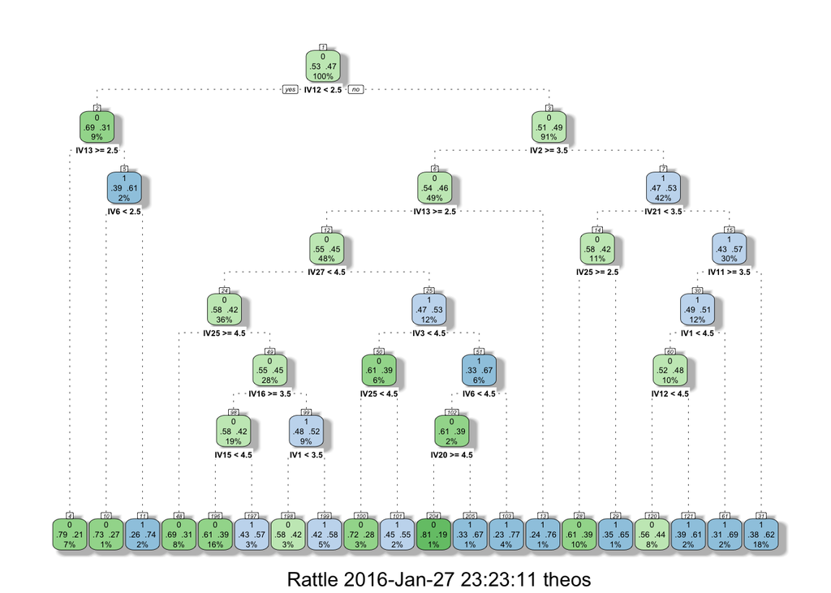

```r
CART_tree_large <- rpart(formula, data = estimation_data_nolabel, method = "class",
    control = rpart.control(cp = 0.005))

fancyRpartPlot(CART_tree_large)
```

```r
# Small tree:
estimation_Probability_class1_tree <- predict(CART_tree, estimation_data_nolabel)[,
    2]
validation_Probability_class1_tree <- predict(CART_tree, validation_data_nolabel)[,
    2]
test_Probability_class1_tree <- predict(CART_tree, test_data_nolabel)[, 2]

# Large tree:
estimation_Probability_class1_tree_large <- predict(CART_tree_large, estimation_data_nolabel)[,
    2]
validation_Probability_class1_tree_large <- predict(CART_tree_large, validation_data_nolabel)[,
    2]
test_Probability_class1_tree_large <- predict(CART_tree_large, test_data_nolabel)[,
    2]
```

Note the use of the R command `predict`. We can now classify the data (respondents in this case) once we define a **Probability Threshold** (see readings). Everyone “above this probability threshold” will be a “1” (predicted to be a purchaser), and everyone below will be a “0” (predicted to be a non-purchaser). The choice of this probability threshold is very important, and it **largely a business decision** as discussed in the session readinds (why?).

```r
Probability_Threshold = 50  # user-friendly
Probability_Threshold = Probability_Threshold/100  # just make it between 0 and 1
```

```r
# The small tree
estimation_prediction_class_tree = 1 * as.vector(estimation_Probability_class1_tree >
    Probability_Threshold)
validation_prediction_class_tree = 1 * as.vector(validation_Probability_class1_tree >
    Probability_Threshold)
test_prediction_class_tree = 1 * as.vector(test_Probability_class1_tree > Probability_Threshold)
# The large tree:
estimation_prediction_class_tree_large = 1 * as.vector(estimation_Probability_class1_tree_large >
    Probability_Threshold)
validation_prediction_class_tree_large = 1 * as.vector(validation_Probability_class1_tree_large >
    Probability_Threshold)
test_prediction_class_tree_large = 1 * as.vector(test_Probability_class1_tree_large >
    Probability_Threshold)
```

and based on it **classify** the respondents:

```r
# Small tree
Classification_Table = rbind(validation_data[, dependent_variable], validation_Probability_class1_tree)
rownames(Classification_Table) <- c("Actual Class", "Probability of Class 1")
colnames(Classification_Table) <- paste("Obs", 1:ncol(Classification_Table),
    sep = " ")
# Large tree
Classification_Table_large = rbind(validation_data[, dependent_variable], validation_Probability_class1_tree)
rownames(Classification_Table_large) <- c("Actual Class", "Probability of Class 1")
colnames(Classification_Table_large) <- paste("Obs", 1:ncol(Classification_Table_large),
    sep = " ")
```

#### Step 5: Assess the accuracy of classification in the first validation sample AND Step 6: Finally, assess the accuracy of classification in the test data.

Now we can see the performances on the 3 data samples we defined. There are a number of performances we can use, as explained in the session readings, such as:

1. **Hit Ratio**
2. **Confusion Table**
3. **ROC Curve**
4. **Lift Curve**
5. **Profit Curve**

For now let’s only see the hit rates and the confusion table for the validation sample.

Now let’s see the hit ratios and confusion matrices for the small and large trees. The **Hit Ratios** first:

```r
validation_actual = validation_data[, dependent_variable]
validation_predictions = rbind(validation_prediction_class_tree, validation_prediction_class_tree_large)
validation_hit_rates = rbind(100 * sum(validation_prediction_class_tree == validation_actual)/length(validation_actual),
    100 * sum(validation_prediction_class_tree_large == validation_actual)/length(validation_actual))
colnames(validation_hit_rates) <- "Hit Ratio"
rownames(validation_hit_rates) <- c("First CART", "Second CART")
```

Validation Data Hit Ratios for different classifiers tested

|  | Hit Ratio |
| --- | --- |
| First CART | 49.0 |
| Second CART | 52.2 |

The **Confusion Matrix**:

```r
validation_prediction_best = validation_predictions[which.max(validation_hit_rates),
    ]
conf_matrix = matrix(rep(0, 4), ncol = 2)
conf_matrix[1, 1] <- 100 * sum(validation_prediction_best * validation_data[,
    dependent_variable])/sum(validation_data[, dependent_variable])
conf_matrix[1, 2] <- 100 * sum((!validation_prediction_best) * validation_data[,
    dependent_variable])/sum(validation_data[, dependent_variable])
conf_matrix[2, 1] <- 100 * sum((!validation_prediction_best) * (!validation_data[,
    dependent_variable]))/sum((!validation_data[, dependent_variable]))
conf_matrix[2, 2] <- 100 * sum((validation_prediction_best) * (!validation_data[,
    dependent_variable]))/sum((!validation_data[, dependent_variable]))
conf_matrix = round(conf_matrix, 2)

colnames(conf_matrix) <- c("Predicted 1", "Predicted 0")
rownames(conf_matrix) <- c("Actual 1", "Actual 0")

print(xtable(conf_matrix, caption = "Confusion Matrix for Validation data",
    digits = 1, ), type = "html", html.table.attributes = "class='table table-striped table-hover table-bordered'",
    caption.placement = "top", comment = FALSE)
```

Confusion Matrix for Validation data

|  | Predicted 1 | Predicted 0 |
| --- | --- | --- |
| Actual 1 | 49.3 | 50.7 |
| Actual 0 | 58.1 | 41.9 |

## Questions

1. Why are the Hit Ratios and Confusion Matrices different for the two trees? Which tree is better in terms of performance so far?
2. How do you expect the performance to behave as you make the tree larger? (**Note:** this is a very important point in machine learning and data analytics in general, so you should elaborate as much as possible).

## Answers:

### Drivers and Business Interpretation

```r
# Small tree
tree_importance = CART_tree$variable.importance
tree_ordered_drivers = as.numeric(gsub("\\IV", " ", names(CART_tree$variable.importance)))
tree_importance_final = rep(0, length(independent_variables))
tree_importance_final[tree_ordered_drivers] <- tree_importance
tree_importance_final <- tree_importance_final/max(abs(tree_importance_final))
# Large tree
large_tree_importance = CART_tree_large$variable.importance
large_tree_ordered_drivers = as.numeric(gsub("\\IV", " ", names(CART_tree_large$variable.importance)))
large_tree_importance_final = rep(0, length(independent_variables))
large_tree_importance_final[large_tree_ordered_drivers] <- large_tree_importance
large_tree_importance_final <- large_tree_importance_final/max(abs(large_tree_importance_final))

Importance_table <- cbind(tree_importance_final, large_tree_importance_final)
colnames(Importance_table) <- c("CART small", "CART large")
rownames(Importance_table) <- paste("Question ", rownames(validation_data)[independent_variables],
    sep = "")
## printing the result in a clean-slate table
```

Clearly there are **many** variations one can explore (How many?!). For our business decisions we can use for example the [analysis here](http://inseaddataanalytics.github.io/INSEADAnalytics/SampleBoatsDriversSegments.html).

**Questions:**

1. Which of the solutions in the analysis report above would you choose? Why?
2. Based on this same report, what is the business profit the company can achieve based on all analyses so far?

**Answers:**

As always **Have Fun**